# In case 4 seats - 2 lines

Fukumoto Tomoya

## ４席２列の場合

### transaction

[interactive chart not shown]

### Simulation

Policy Pij_k は 状態 $(i.j)$ のときに$k$人のグループが来たときにどの列へ案内するかという方策を指す。 Policy Pij_kが `TRUE` とは前の列に案内すること、 `FALSE` は後ろの列に案内することを意味する。

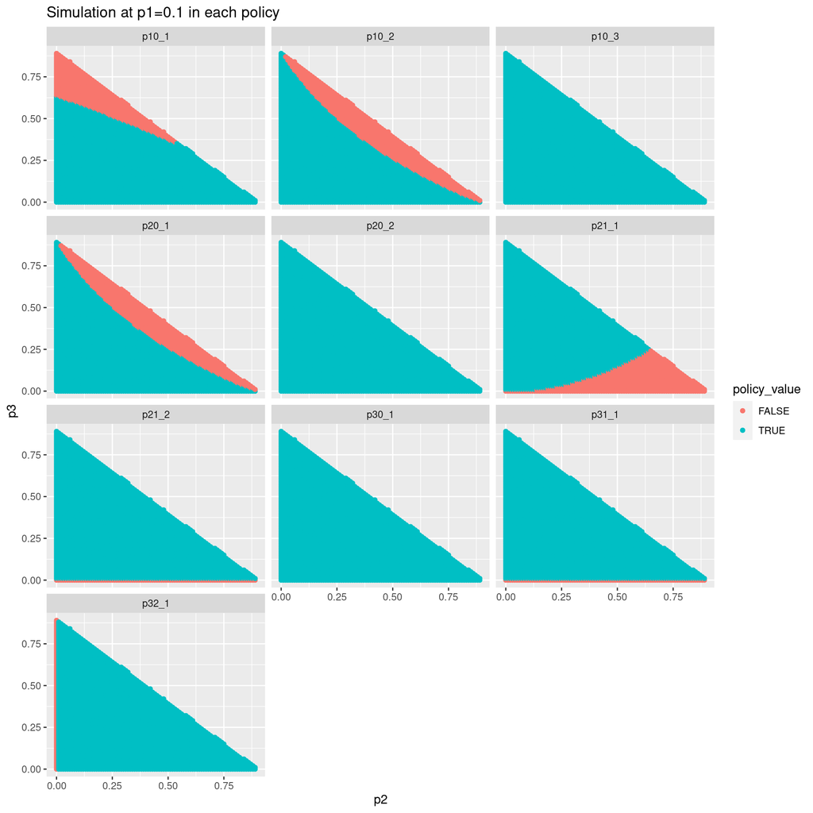

また (P10_2, P20_1), (P21_2, P31_1) のペアは対応しており全く同じ条件で最適方策が切り替わる。 これはこの条件で席を案内したあとに得られる状態が全く同じなので当然である。

P10_1, P10_2, P21_1について細かく見る。

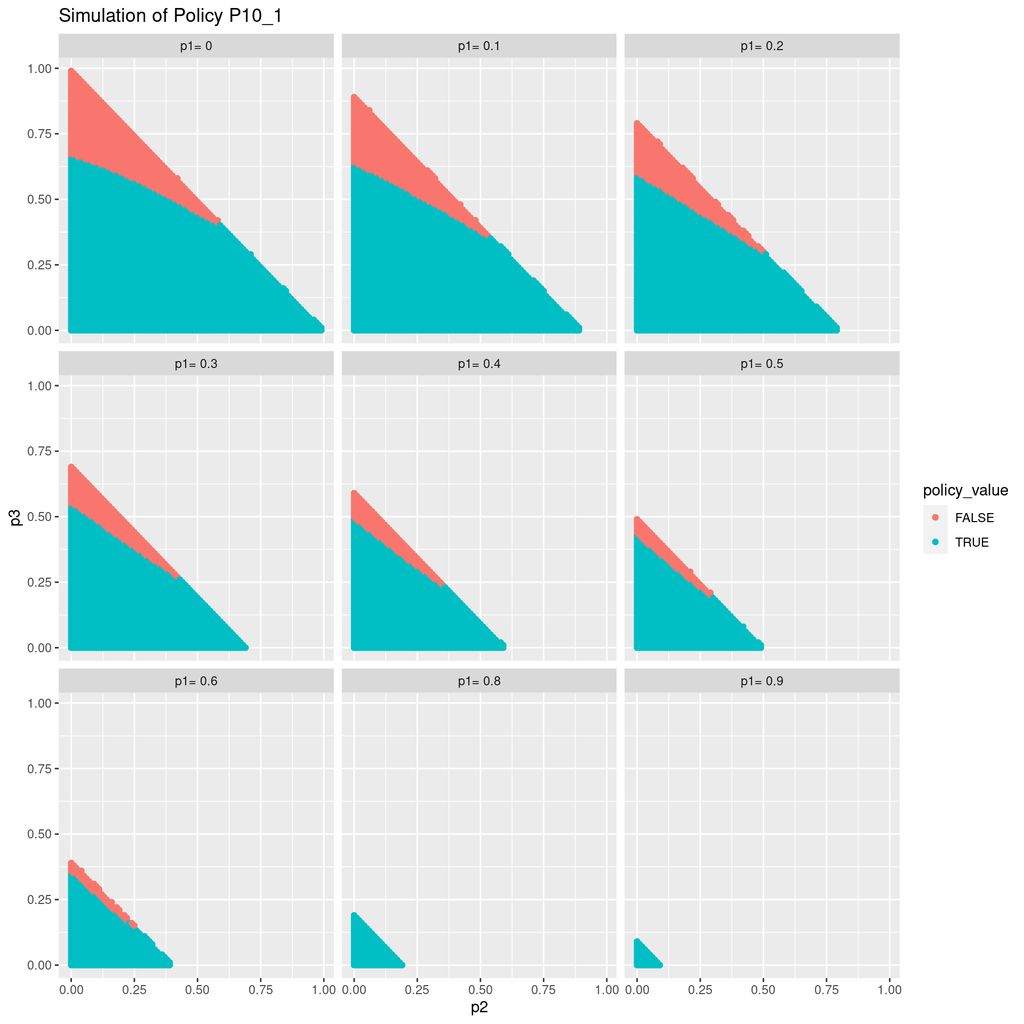

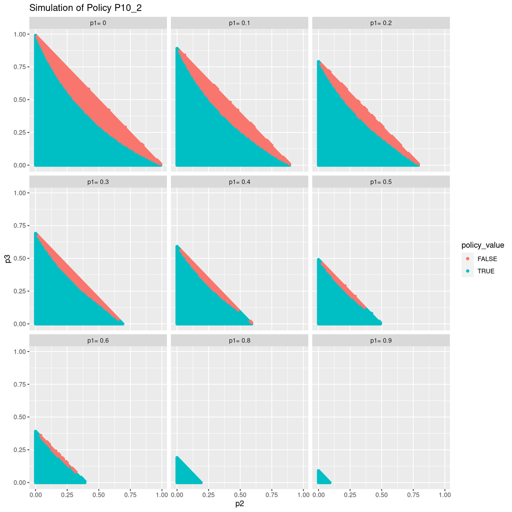

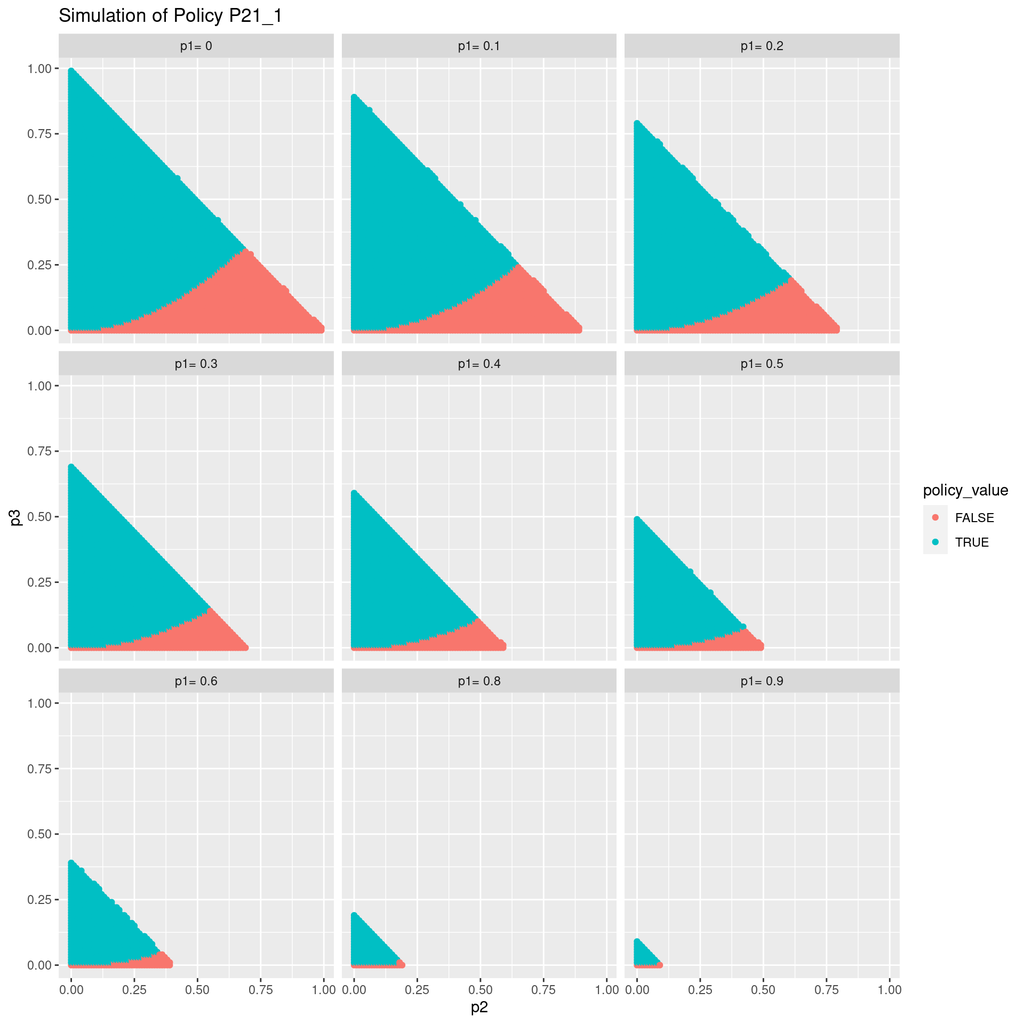

## Transfer matrix

状態ベクトルを次のようにとる。
$$s = \left(s_{10},s_{20},s_{11},s_{30},s_{21},s_{40},s_{31},s_{22},s_{41},s_{32},s_{42},s_{33},s_{41},s_{44}\right)$$
このとき転送行列は次のように書ける。

$$T = U + D$$

$$U = \begin{pmatrix}
0 & \pi_{10}^1 & \pi_{10}^1 & \pi_{10}^2 & \pi_{10}^2 & \pi_{10}^3 & \pi_{10}^3 & 0 & p_4 & 0 & 0& 0 & 0 & 0 \\
0 & 0 & 0 & \pi_{20}^1 & \pi_{20}^1 & \pi_{20}^2 & 0 & \pi_{20}^2 & 0 & p_3 & p_4 & 0 & 0 & 0\\
0 & 0 & 0 & 0 & p_1 & 0 & p_2 & 0 & p_3 & 0 & 0 & 0 & 0 & 0\\
0 & 0 & 0 & 0 & 0 & \pi_{30}^1 & \pi_{30}^1 & 0 & 0 & p_2 & 0 & p_3 & p_4 & 0\\
0 & 0 & 0 & 0 & 0 & 0 & \pi_{21}^1 & \pi_{21}^1 & \pi_{21}^2 & \pi_{21}^2 & p_3 & 0 & 0 & 0\\
0 & 0 & 0 & 0 & 0 & 0 & 0 & 0 & p_1 & 0 & p_2 & 0 & p_3 & p_4\\
0 & 0 & 0 & 0 & 0 & 0 & 0 & 0 & \pi_{31}^1 & \pi_{31}^1 & 0 & p_2 & p_3 & 0\\
0 & 0 & 0 & 0 & 0 & 0 & 0 & 0 & 0 & p_1 & p_2 & 0 & 0 & 0\\
0 & 0 & 0 & 0 & 0 & 0 & 0 & 0 & 0 & 0 & p_1 & 0 & p_2 & p_3\\
0 & 0 & 0 & 0 & 0 & 0 & 0 & 0 & 0 & 0 & \pi_{32}^1 & \pi_{32}^1 & p_2 & 0\\
0 & 0 & 0 & 0 & 0 & 0 & 0 & 0 & 0 & 0 & 0 & 0 & p_1 & p_2\\
0 & 0 & 0 & 0 & 0 & 0 & 0 & 0 & 0 & 0 & 0 & 0 & p_1 & 0\\
0 & 0 & 0 & 0 & 0 & 0 & 0 & 0 & 0 & 0 & 0 & 0 & 0 & p_1\\
0 & 0 & 0 & 0 & 0 & 0 & 0 & 0 & 0 & 0 & 0 & 0 & 0 & 0\\
\end{pmatrix}$$

$$D = \begin{pmatrix}
0 & 0 & 0 & 0 & 0 & 0 & 0 & 0 & 0 & 0 & 0 & 0 & 0 & 0\\
0 & 0 & 0 & 0 & 0 & 0 & 0 & 0 & 0 & 0 & 0 & 0 & 0 & 0\\
0 & 0 & 0 & 0 & 0 & p_4 & 0 & 0 & 0 & 0 & 0 & 0 & 0 & 0\\
0 & 0 & 0 & 0 & 0 & 0 & 0 & 0 & 0 & 0 & 0 & 0 & 0 & 0\\
0 & 0 & 0 & 0 & 0 & p_4 & 0 & 0 & 0 & 0 & 0 & 0 & 0 & 0\\
0 & 0 & 0 & 0 & 0 & 0 & 0 & 0 & 0 & 0 & 0 & 0 & 0 & 0\\
0 & 0 & 0 & 0 & 0 & p_4 & 0 & 0 & 0 & 0 & 0 & 0 & 0 & 0\\
0 & 0 & 0 & p_3 & 0 & p_4 & 0 & 0 & 0 & 0 & 0 & 0 & 0 & 0\\
0 & 0 & 0 & 0 & 0 & p_4 & 0 & 0 & 0 & 0 & 0 & 0 & 0 & 0\\
0 & 0 & 0 & p_3 & 0 & p_4 & 0 & 0 & 0 & 0 & 0 & 0 & 0 & 0\\
0 & 0 & 0 & p_3 & 0 & p_4 & 0 & 0 & 0 & 0 & 0 & 0 & 0 & 0\\
0 & p_2 & 0 & p_3 & 0 & p_4 & 0 & 0 & 0 & 0 & 0 & 0 & 0 & 0\\
0 & p_2 & 0 & p_3 & 0 & p_4 & 0 & 0 & 0 & 0 & 0 & 0 & 0 & 0\\
p_1 & p_2 & 0 & p_3 & 0 & p_4 & 0 & 0 & 0 & 0 & 0 & 0 & 0 & 0\\
\end{pmatrix}$$